# ASSIGNMENT3

Juan Francisco H.dez F.dez

# **The Problem**

The goal of this assignment is to create a regression model that would accurately predict housing prices in Kings County, Washington.

**Research question**: How do features indicating characteristics of homes sold (bedrooms, year of contruction, grade…) effect house price?

# **The data**

For this analysis we will use king.csv file which contains data on sales in in Kings County, Washington from 5/2/2014 to 5/27/2015.

**The response variable is:**

- price: Selling price of the house.

**And the explanatory variables are:**

- id: Unique ID for a house.
- bedrooms: Number of bedrooms.
- bathrooms: Number of bathrooms.
- sqft_living: square footage of the home.
- sqft_lot: square footage of the lot.
- floors: Total floors (levels) in house.
- waterfront: Whether house has a view to a waterfront.
- view: Number of times house has been viewed.
- condition: How good the condition is (overall).
- grade: overall grade given to the housing unit, based on King County grading system.
- sqft_above: square footage of house (apart from basement).
- sqft_basement: square footage of the basement.
- yr_built: Year when house was built.
- yr_renovated: Year when house was renovated.
- zipcode: zip code in which house is located.
- lat: Latitude coordinate.
- long: Longitude coordinate.
- sqft_living15: The square footage of interior housing living space for the nearest 15 neighbors.
- sqft_lot15: The square footage of the land lots of the nearest 15 neighbors.
- sqft_above: square footage of house (apart from basement).
- sqft_basement: square footage of the basement.

```r
library(corrplot)
data <- read.csv(file = 'data/king.csv')
```

### **Exploring the data**

First let’s look at the more general characteristics of our data.

```r
str(data)
```

```
## 'data.frame':    16187 obs. of  22 variables:
##  $ X            : int  1 2 3 4 5 6 7 8 9 10 ...
##  $ ID           : int  1 2 3 4 5 6 7 8 9 10 ...
##  $ price        : int  221900 538000 180000 510000 1230000 257500 291850 229500 323000 662500 ...
##  $ bedrooms     : int  3 3 2 3 4 3 3 3 3 3 ...
##  $ bathrooms    : num  1 2.25 1 2 4.5 2.25 1.5 1 2.5 2.5 ...
##  $ sqft_living  : int  1180 2570 770 1680 5420 1715 1060 1780 1890 3560 ...
##  $ sqft_lot     : int  5650 7242 10000 8080 101930 6819 9711 7470 6560 9796 ...
##  $ floors       : num  1 2 1 1 1 2 1 1 2 1 ...
##  $ waterfront   : int  0 0 0 0 0 0 0 0 0 0 ...
##  $ view         : int  0 0 0 0 0 0 0 0 0 0 ...
##  $ condition    : int  3 3 3 3 3 3 3 3 3 3 ...
##  $ grade        : int  7 7 6 8 11 7 7 7 7 8 ...
##  $ sqft_above   : int  1180 2170 770 1680 3890 1715 1060 1050 1890 1860 ...
##  $ sqft_basement: int  0 400 0 0 1530 0 0 730 0 1700 ...
##  $ yr_built     : int  1955 1951 1933 1987 2001 1995 1963 1960 2003 1965 ...
##  $ yr_renovated : int  0 1991 0 0 0 0 0 0 0 0 ...
##  $ renovated    : int  0 1 0 0 0 0 0 0 0 0 ...
##  $ zipcode      : int  98178 98125 98028 98074 98053 98003 98198 98146 98038 98007 ...
##  $ lat          : num  47.5 47.7 47.7 47.6 47.7 ...
##  $ long         : num  -122 -122 -122 -122 -122 ...
##  $ sqft_living15: int  1340 1690 2720 1800 4760 2238 1650 1780 2390 2210 ...
##  $ sqft_lot15   : int  5650 7639 8062 7503 101930 6819 9711 8113 7570 8925 ...
```

```r
summary(data)
```

```
##        X               ID            price            bedrooms
##  Min.   :    1   Min.   :    1   Min.   :  75000   Min.   : 0.000
##  1st Qu.: 4048   1st Qu.: 4048   1st Qu.: 324624   1st Qu.: 3.000
##  Median : 8094   Median : 8094   Median : 451000   Median : 3.000
##  Mean   : 8094   Mean   : 8094   Mean   : 542802   Mean   : 3.374
##  3rd Qu.:12140   3rd Qu.:12140   3rd Qu.: 648876   3rd Qu.: 4.000
##  Max.   :16187   Max.   :16187   Max.   :7700000   Max.   :33.000
##    bathrooms      sqft_living       sqft_lot           floors
##  Min.   :0.000   Min.   :  370   Min.   :    520   Min.   :1.000
##  1st Qu.:1.750   1st Qu.: 1420   1st Qu.:   5040   1st Qu.:1.000
##  Median :2.250   Median : 1920   Median :   7600   Median :1.500
##  Mean   :2.117   Mean   : 2084   Mean   :  15069   Mean   :1.495
##  3rd Qu.:2.500   3rd Qu.: 2550   3rd Qu.:  10696   3rd Qu.:2.000
##  Max.   :8.000   Max.   :12050   Max.   :1651359   Max.   :3.500
##    waterfront            view          condition         grade
##  Min.   :0.000000   Min.   :0.0000   Min.   :1.000   Min.   : 3.000
##  1st Qu.:0.000000   1st Qu.:0.0000   1st Qu.:3.000   1st Qu.: 7.000
##  Median :0.000000   Median :0.0000   Median :3.000   Median : 7.000
##  Mean   :0.007599   Mean   :0.2435   Mean   :3.409   Mean   : 7.661
##  3rd Qu.:0.000000   3rd Qu.:0.0000   3rd Qu.:4.000   3rd Qu.: 8.000
##  Max.   :1.000000   Max.   :4.0000   Max.   :5.000   Max.   :13.000
##    sqft_above   sqft_basement       yr_built     yr_renovated
##  Min.   : 370   Min.   :   0.0   Min.   :1900   Min.   :   0.00
##  1st Qu.:1190   1st Qu.:   0.0   1st Qu.:1951   1st Qu.:   0.00
##  Median :1560   Median :   0.0   Median :1975   Median :   0.00
##  Mean   :1791   Mean   : 292.9   Mean   :1971   Mean   :  83.24
##  3rd Qu.:2220   3rd Qu.: 570.0   3rd Qu.:1997   3rd Qu.:   0.00
##  Max.   :8860   Max.   :4820.0   Max.   :2015   Max.   :2015.00
##    renovated         zipcode           lat             long
##  Min.   :0.0000   Min.   :98001   Min.   :47.16   Min.   :-122.5
##  1st Qu.:0.0000   1st Qu.:98033   1st Qu.:47.47   1st Qu.:-122.3
##  Median :0.0000   Median :98065   Median :47.57   Median :-122.2
##  Mean   :0.0417   Mean   :98078   Mean   :47.56   Mean   :-122.2
##  3rd Qu.:0.0000   3rd Qu.:98118   3rd Qu.:47.68   3rd Qu.:-122.1
##  Max.   :1.0000   Max.   :98199   Max.   :47.78   Max.   :-121.3
##  sqft_living15    sqft_lot15
##  Min.   : 399   Min.   :   651
##  1st Qu.:1490   1st Qu.:  5100
##  Median :1840   Median :  7601
##  Mean   :1990   Mean   : 12678
##  3rd Qu.:2370   3rd Qu.: 10080
##  Max.   :6210   Max.   :871200
```

As we can see with respect to the dependent variable price, its mean is slightly higher than its median, which helps us to understand the limitations of a linear model with these data.We also observed some outliers in the bedrooms variable, as a house with 0 rooms does not make any sense and a house with 33 rooms does not make any sense either.Morveover, we have the variable bathrooms, which also presents a minimum value of 0 which as with rooms, seems to make little sense since the minimum per house should be one bathroom.

### **Cleaning the data**

To clean our data, we will remove the outliers of the variable rooms and for the variable bathrooms, we will replace those values less than 1 by 1. We will also remove the variables id, X and zip code as they do not provide us with any information regarding the problem we want to solve. In the case of id and X, they do not contribute because they are indexes and in the case of the postal code, it does not contribute anything because we already have the position coordinates which are more exact and contribute more than the postal code.

```r
data <- data[3:22]
data <- data[,-16]
outliersBedroom <- boxplot(data$bedrooms, plot=FALSE)$out
data<- data[-which(data$bedrooms %in% outliersBedroom),]
data$bathrooms[data$bathrooms<1] <- 1
summary(data)
```

```
##      price            bedrooms       bathrooms      sqft_living
##  Min.   :  78000   Min.   :2.000   Min.   :1.000   Min.   :  440
##  1st Qu.: 324950   1st Qu.:3.000   1st Qu.:1.750   1st Qu.: 1430
##  Median : 450000   Median :3.000   Median :2.250   Median : 1910
##  Mean   : 539747   Mean   :3.347   Mean   :2.111   Mean   : 2074
##  3rd Qu.: 645000   3rd Qu.:4.000   3rd Qu.:2.500   3rd Qu.: 2538
##  Max.   :7060000   Max.   :5.000   Max.   :6.750   Max.   :10040
##     sqft_lot           floors        waterfront            view
##  Min.   :    520   Min.   :1.000   Min.   :0.000000   Min.   :0.0000
##  1st Qu.:   5040   1st Qu.:1.000   1st Qu.:0.000000   1st Qu.:0.0000
##  Median :   7599   Median :1.500   Median :0.000000   Median :0.0000
##  Mean   :  15006   Mean   :1.496   Mean   :0.007358   Mean   :0.2379
##  3rd Qu.:  10631   3rd Qu.:2.000   3rd Qu.:0.000000   3rd Qu.:0.0000
##  Max.   :1651359   Max.   :3.500   Max.   :1.000000   Max.   :4.0000
##    condition         grade         sqft_above   sqft_basement       yr_built
##  Min.   :1.000   Min.   : 4.00   Min.   : 440   Min.   :   0.0   Min.   :1900
##  1st Qu.:3.000   1st Qu.: 7.00   1st Qu.:1200   1st Qu.:   0.0   1st Qu.:1952
##  Median :3.000   Median : 7.00   Median :1560   Median :   0.0   Median :1975
##  Mean   :3.409   Mean   : 7.67   Mean   :1787   Mean   : 286.3   Mean   :1971
##  3rd Qu.:4.000   3rd Qu.: 8.00   3rd Qu.:2210   3rd Qu.: 550.0   3rd Qu.:1997
##  Max.   :5.000   Max.   :13.00   Max.   :7880   Max.   :4820.0   Max.   :2015
##   yr_renovated       renovated           lat             long
##  Min.   :   0.00   Min.   :0.0000   Min.   :47.16   Min.   :-122.5
##  1st Qu.:   0.00   1st Qu.:0.0000   1st Qu.:47.47   1st Qu.:-122.3
##  Median :   0.00   Median :0.0000   Median :47.57   Median :-122.2
##  Mean   :  81.04   Mean   :0.0406   Mean   :47.56   Mean   :-122.2
##  3rd Qu.:   0.00   3rd Qu.:0.0000   3rd Qu.:47.68   3rd Qu.:-122.1
##  Max.   :2015.00   Max.   :1.0000   Max.   :47.78   Max.   :-121.3
##  sqft_living15    sqft_lot15
##  Min.   : 399   Min.   :   651
##  1st Qu.:1490   1st Qu.:  5100
##  Median :1840   Median :  7614
##  Mean   :1990   Mean   : 12621
##  3rd Qu.:2370   3rd Qu.: 10080
##  Max.   :6210   Max.   :871200
```

### **Distribution of the variables and relationship to the dependent variable**

Now that we have our data cleaned, let’s analyse them one by one in order to better understand their distributions and their significance with respect to the dependent variable.For the distributions we will use a histogram, which will allow us to analyse them from an optical point of view, and for their relationship with the price variable we will use a scatterplot.

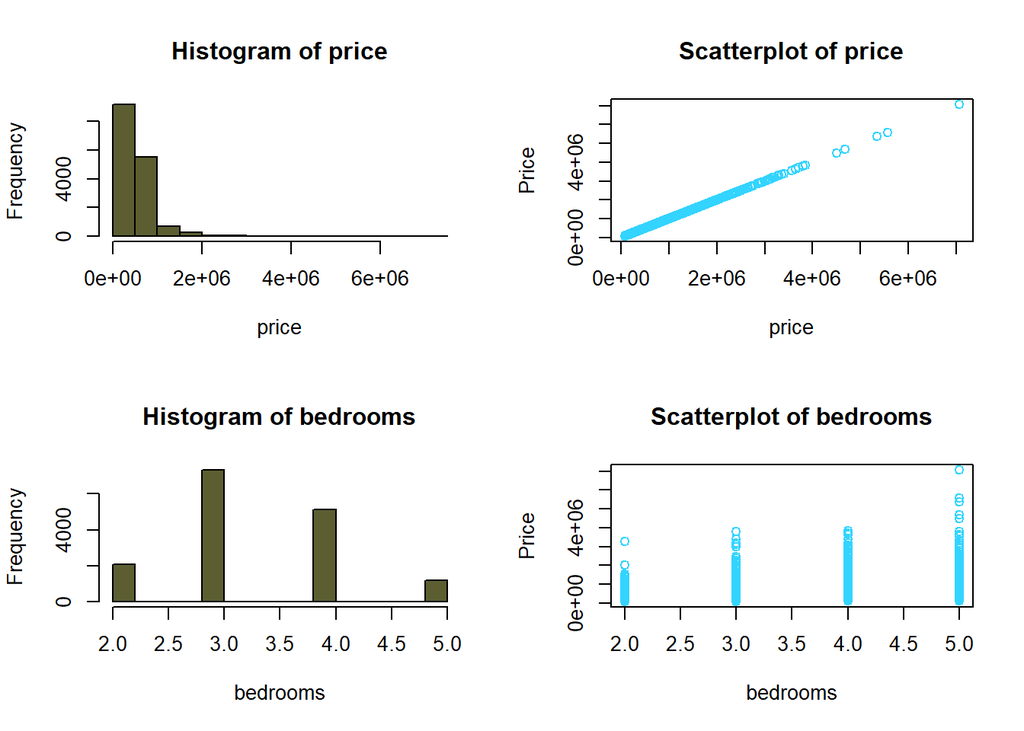

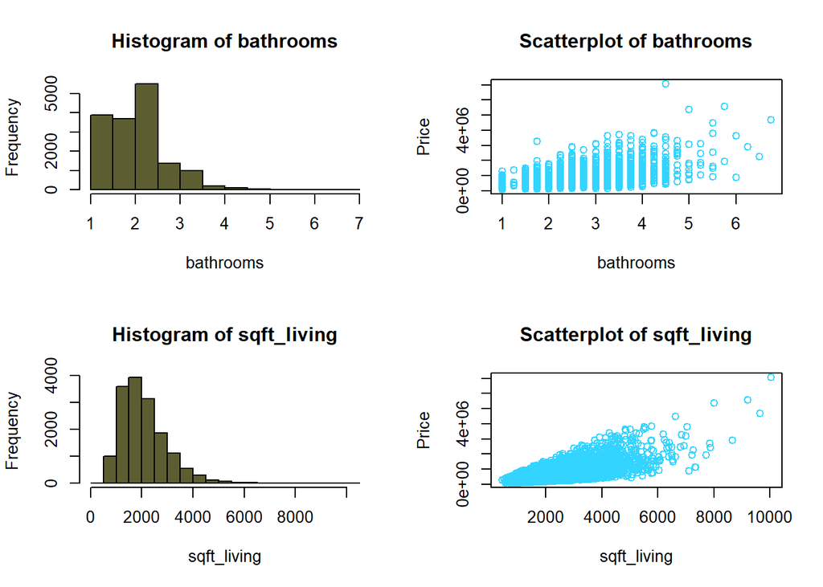

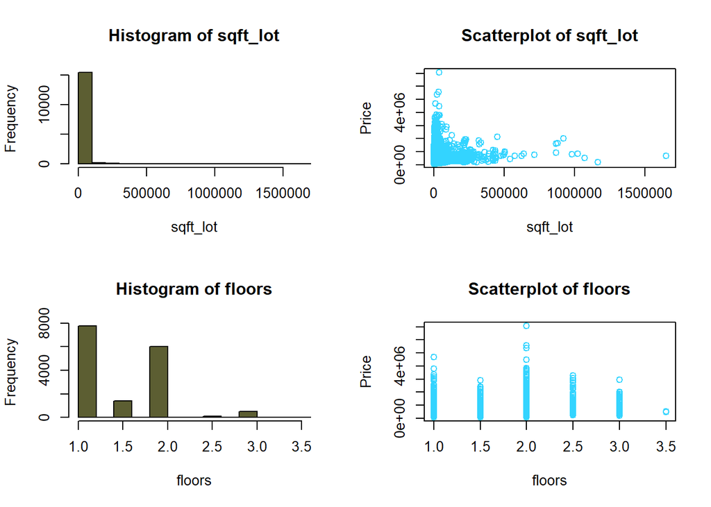

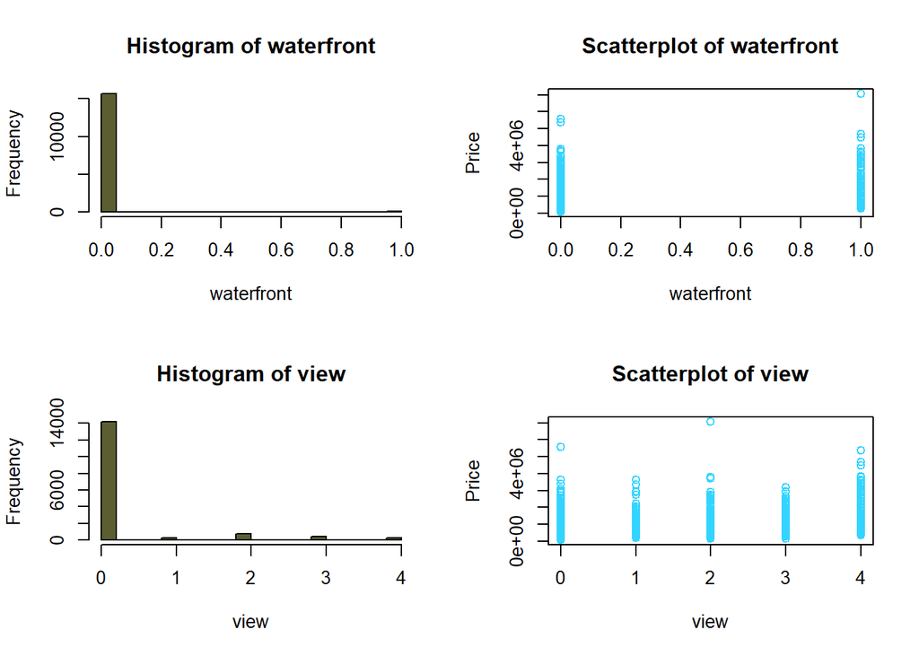

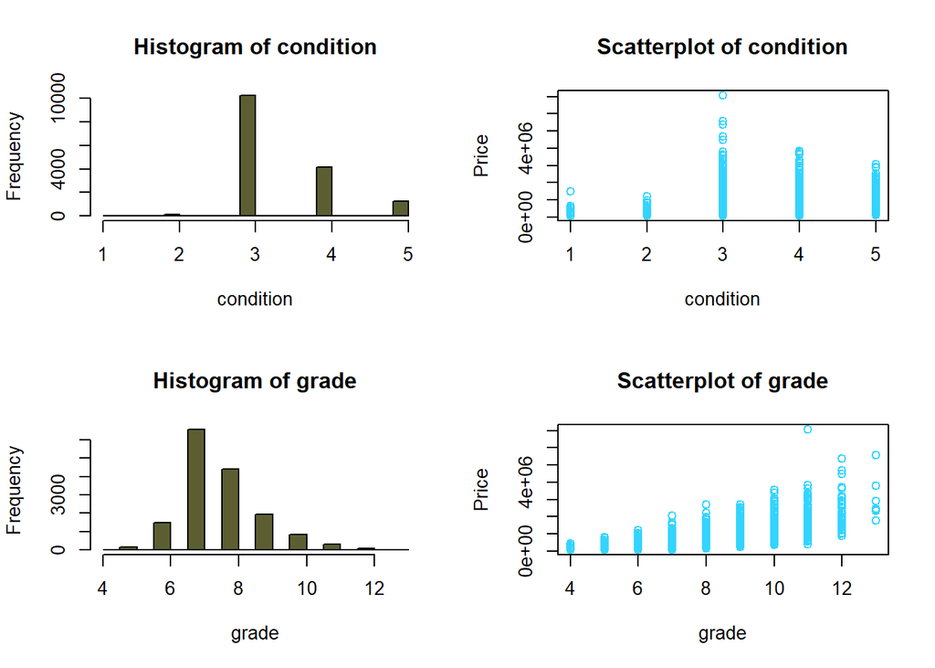

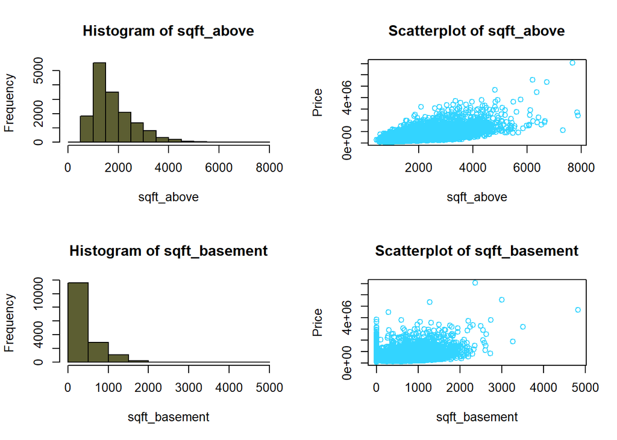

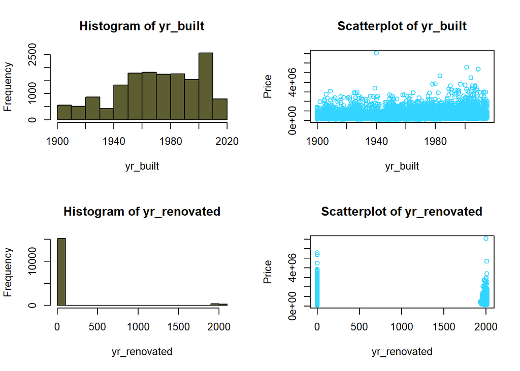

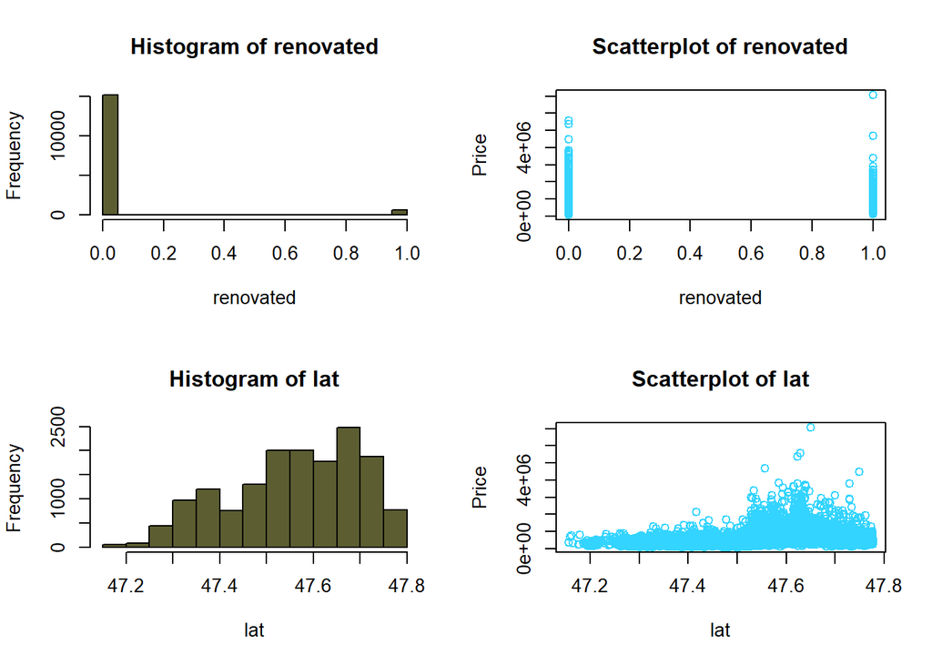

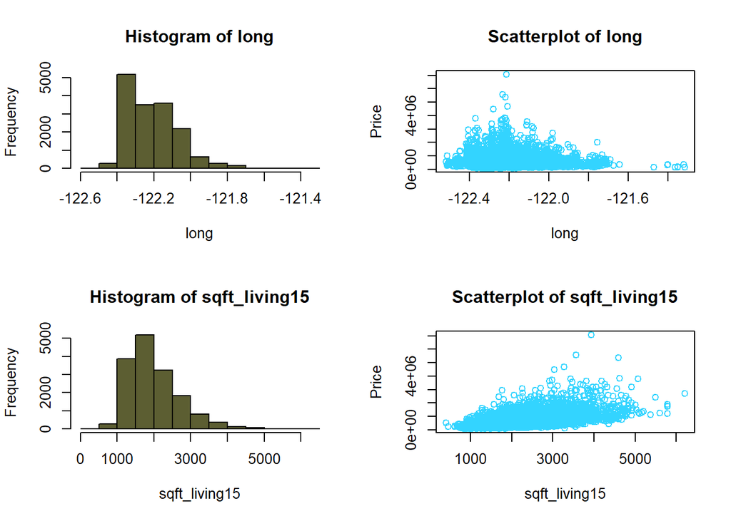

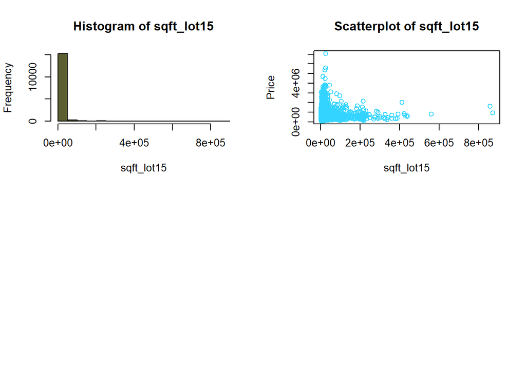

```r
len <- length(colnames(data))
par(mfrow = c(2, 2))

for(i in 1:len){
  column = colnames(data)[i]
  main = paste("Histogram of",column,sep=" ")
  hist(data[,i],main=main,xlab = column,col="#5C5E32")
  main = paste("Scatterplot of",column,sep=" ")
  plot(data$price ~ data[,i],main=main, data=data,
   xlab=column, ylab="Price", col = "#33D4FF")
}
```

### **Relationships among features, the correlation matrix:**

Finally, we will use a correlation matrix in order to also understand the relationships between all the variables.

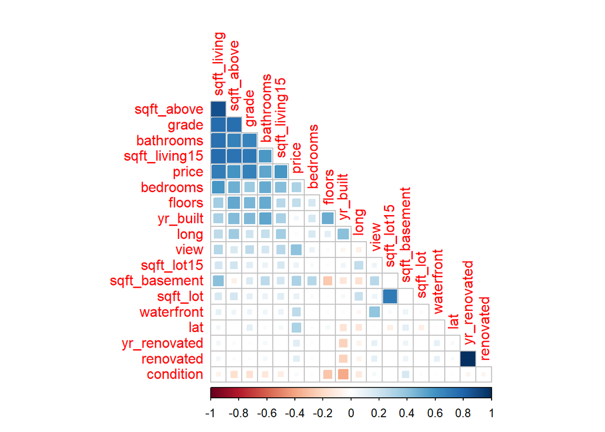

```r
Cor = cor(data)
corrplot(Cor, method = 'square', order = 'FPC', type = 'lower', diag = FALSE)
```

# **The models**

### **First attempt**

We will start fitting a linear regression model relating all the independent variables to the price and then we will have a first model to work on.

```r
model1 <- lm(data$price~., data = data)
summary(model1)
```

```
##
## Call:
## lm(formula = data$price ~ ., data = data)
##
## Residuals:
##      Min       1Q   Median       3Q      Max
## -1088832   -97242    -9753    75457  3996577
##
## Coefficients: (1 not defined because of singularities)
##                 Estimate Std. Error t value Pr(>|t|)
## (Intercept)   -3.592e+07  1.841e+06 -19.513  < 2e-16 ***
## bedrooms      -3.314e+04  2.504e+03 -13.234  < 2e-16 ***
## bathrooms      4.060e+04  3.843e+03  10.566  < 2e-16 ***
## sqft_living    1.388e+02  5.121e+00  27.106  < 2e-16 ***
## sqft_lot       1.587e-01  5.271e-02   3.011  0.00261 **
## floors         3.544e+03  4.096e+03   0.865  0.38698
## waterfront     5.603e+05  2.008e+04  27.909  < 2e-16 ***
## view           5.144e+04  2.419e+03  21.263  < 2e-16 ***
## condition      3.252e+04  2.696e+03  12.062  < 2e-16 ***
## grade          9.876e+04  2.494e+03  39.597  < 2e-16 ***
## sqft_above     2.909e+01  5.051e+00   5.760 8.57e-09 ***
## sqft_basement         NA         NA      NA       NA
## yr_built      -2.389e+03  8.332e+01 -28.672  < 2e-16 ***
## yr_renovated   3.393e+03  4.973e+02   6.821 9.34e-12 ***
## renovated     -6.729e+06  9.928e+05  -6.778 1.26e-11 ***
## lat            5.601e+05  1.199e+04  46.704  < 2e-16 ***
## long          -1.085e+05  1.385e+04  -7.834 5.01e-15 ***
## sqft_living15  3.028e+01  3.947e+00   7.673 1.78e-14 ***
## sqft_lot15    -3.706e-01  8.226e-02  -4.506 6.65e-06 ***
## ---
## Signif. codes:  0 '***' 0.001 '**' 0.01 '*' 0.05 '.' 0.1 ' ' 1
##
## Residual standard error: 196600 on 15747 degrees of freedom
## Multiple R-squared:  0.6963, Adjusted R-squared:  0.696
## F-statistic:  2124 on 17 and 15747 DF,  p-value: < 2.2e-16
```

If the residuals are distributed according to a normal distribution we should expect the median to be 0 or very close to 0, and the 1st and 3rd quartiles to be symmetric. The same for the minimum or maximum values. In this case there are notable deviations of mean and median and there is no symmetry between quartiles so it is very likely that we are not complying with some of the assumptions of the linear models.Another interesting fact that we can extract from the summary is that the intercept appears as negative, this does not seem to indicate that something is wrong with our model since our price variable does not make sense in a negative value. However, we can observe an adjusted R-squared of 0.696, which tells us that a percentage of 69.6% of the variation of the dependent variable is collectively explained by all the independent variables, so we can consider that the model does not perform badly at all.

### **Second attempt**

We will test a second model using the variables that are most highly correlated with the dependent variable, assuming that these are the most significant.We are also going to remove the sqft_basement variable since, according to all the models returned, it does not seem to contribute any information to the model.

```r
data <- data[,-12]
model2 <- lm(data$price~data$sqft_living+data$sqft_living15+data$sqft_above+data$bathrooms+data$grade, data = data)
summary(model2)
```

```
##
## Call:
## lm(formula = data$price ~ data$sqft_living + data$sqft_living15 +
##     data$sqft_above + data$bathrooms + data$grade, data = data)
##
## Residuals:
##     Min      1Q  Median      3Q     Max
## -927204 -132156  -22457   97007 4773418
##
## Coefficients:
##                      Estimate Std. Error t value Pr(>|t|)
## (Intercept)        -6.626e+05  1.557e+04 -42.566  < 2e-16 ***
## data$sqft_living    2.405e+02  5.263e+00  45.694  < 2e-16 ***
## data$sqft_living15  2.496e+01  4.606e+00   5.419 6.09e-08 ***
## data$sqft_above    -8.775e+01  5.107e+00 -17.181  < 2e-16 ***
## data$bathrooms     -3.563e+04  4.002e+03  -8.904  < 2e-16 ***
## data$grade          1.155e+05  2.841e+03  40.663  < 2e-16 ***
## ---
## Signif. codes:  0 '***' 0.001 '**' 0.01 '*' 0.05 '.' 0.1 ' ' 1
##
## Residual standard error: 241000 on 15759 degrees of freedom
## Multiple R-squared:  0.5429, Adjusted R-squared:  0.5428
## F-statistic:  3744 on 5 and 15759 DF,  p-value: < 2.2e-16
```

As we can see again in the model summary, the problems previously presented by the model have not been solved, and furthermore, the results with respect to the adjusted R-squared have worsened. This may be due to the fact that although we are using the variables that are most correlated with respect to the dependent variable assuming that each feature’s individual contribution to the outcome, we are ignoring the possibility that features could have a combined impact on the dependent variable.

### **Third attempt**

We will introduce into the model some interaction effects in order to check whether the model does indeed improve by introducing these combinations. For this purpose, I will assume that there is an interaction between the number of floors and the square metres, since I assume that a house with exactly the same number of square metres could have a higher price if it has more floors. I will also assume the same between the square metres of land and the grade it has, and likewise with the number of bedrooms and the number of bathrooms, as I assume that a house with 5 bedrooms and only one bathroom cannot have the same value as one with the same number of bedrooms but with 5 bathrooms.

```r
data2 <- data
data2$conbuil <- (data$sqft_living*data$floors)
data2$sqftGr <- (data$sqft_lot*data$grade)
data2$bedbath <- (data$bedrooms*data$bathrooms)
model3 <- lm(price~., data = data2)
summary(model3)
```

```
##
## Call:
## lm(formula = price ~ ., data = data2)
##
## Residuals:
##      Min       1Q   Median       3Q      Max
## -1346371   -95445   -10193    74830  3864419
##
## Coefficients:
##                 Estimate Std. Error t value Pr(>|t|)
## (Intercept)   -3.447e+07  1.820e+06 -18.946  < 2e-16 ***
## bedrooms      -1.160e+05  5.828e+03 -19.904  < 2e-16 ***
## bathrooms     -1.066e+05  9.839e+03 -10.831  < 2e-16 ***
## sqft_living    9.090e+01  7.607e+00  11.950  < 2e-16 ***
## sqft_lot       2.955e-01  1.736e-01   1.702   0.0888 .
## floors        -4.379e+04  8.776e+03  -4.990 6.11e-07 ***
## waterfront     5.678e+05  1.980e+04  28.673  < 2e-16 ***
## view           5.034e+04  2.387e+03  21.093  < 2e-16 ***
## condition      3.669e+04  2.666e+03  13.761  < 2e-16 ***
## grade          1.030e+05  2.513e+03  40.969  < 2e-16 ***
## sqft_above     1.648e+00  5.497e+00   0.300   0.7643
## yr_built      -2.157e+03  8.321e+01 -25.919  < 2e-16 ***
## yr_renovated   3.259e+03  4.907e+02   6.641 3.21e-11 ***
## renovated     -6.456e+06  9.795e+05  -6.591 4.52e-11 ***
## lat            5.578e+05  1.184e+04  47.108  < 2e-16 ***
## long          -9.664e+04  1.368e+04  -7.062 1.71e-12 ***
## sqft_living15  3.241e+01  3.923e+00   8.262  < 2e-16 ***
## sqft_lot15    -3.264e-01  8.231e-02  -3.965 7.36e-05 ***
## conbuil        3.093e+01  4.199e+00   7.366 1.85e-13 ***
## sqftGr        -1.598e-02  2.083e-02  -0.767   0.4428
## bedbath        4.291e+04  2.614e+03  16.417  < 2e-16 ***
## ---
## Signif. codes:  0 '***' 0.001 '**' 0.01 '*' 0.05 '.' 0.1 ' ' 1
##
## Residual standard error: 193800 on 15744 degrees of freedom
## Multiple R-squared:  0.7047, Adjusted R-squared:  0.7043
## F-statistic:  1879 on 20 and 15744 DF,  p-value: < 2.2e-16
```

### **Fourth attempt**

For this new attempt we will try adding the square of some variables, this allows us to model more accurately the effect of sqft or the year of construction, which as we could see, may have a non-linear relationship with the dependent variable.

```r
data4 <- data
data4$sqft_living2 <- data$sqft_living^2
data4$yr_built2 <- data$yr_built^2
data4$sqft_living152 <- data$sqft_living15^2
data4$sqft_lot2 <- data$sqft_lot^2
data4$sqft_above2 <- data$sqft_above^2
model4 <- lm(price~., data = data4)
summary(model4)
```

```
##
## Call:
## lm(formula = price ~ ., data = data4)
##
## Residuals:
##      Min       1Q   Median       3Q      Max
## -1862408   -89868   -10967    68480  2088369
##
## Coefficients:
##                  Estimate Std. Error t value Pr(>|t|)
## (Intercept)     3.976e+07  7.767e+06   5.119 3.11e-07 ***
## bedrooms       -5.626e+03  2.456e+03  -2.291  0.02198 *
## bathrooms       4.516e+04  3.682e+03  12.267  < 2e-16 ***
## sqft_living    -1.552e+02  9.975e+00 -15.557  < 2e-16 ***
## sqft_lot        3.053e-02  8.366e-02   0.365  0.71519
## floors         -4.425e+03  4.381e+03  -1.010  0.31257
## waterfront      5.225e+05  1.897e+04  27.546  < 2e-16 ***
## view            4.760e+04  2.296e+03  20.735  < 2e-16 ***
## condition       4.203e+04  2.582e+03  16.278  < 2e-16 ***
## grade           1.007e+05  2.356e+03  42.727  < 2e-16 ***
## sqft_above      8.162e+01  1.158e+01   7.050 1.87e-12 ***
## yr_built       -7.758e+04  7.824e+03  -9.917  < 2e-16 ***
## yr_renovated    3.281e+03  4.707e+02   6.970 3.29e-12 ***
## renovated      -6.493e+06  9.397e+05  -6.910 5.04e-12 ***
## lat             5.632e+05  1.136e+04  49.560  < 2e-16 ***
## long           -9.005e+04  1.319e+04  -6.829 8.87e-12 ***
## sqft_living15   3.890e+01  1.203e+01   3.235  0.00122 **
## sqft_lot15     -2.559e-01  8.366e-02  -3.059  0.00223 **
## sqft_living2    5.169e-02  1.582e-03  32.671  < 2e-16 ***
## yr_built2       1.925e+01  1.999e+00   9.631  < 2e-16 ***
## sqft_living152  3.074e-03  2.394e-03   1.284  0.19911
## sqft_lot2       1.291e-07  8.160e-08   1.582  0.11362
## sqft_above2    -1.573e-02  2.202e-03  -7.146 9.31e-13 ***
## ---
## Signif. codes:  0 '***' 0.001 '**' 0.01 '*' 0.05 '.' 0.1 ' ' 1
##
## Residual standard error: 185400 on 15742 degrees of freedom
## Multiple R-squared:  0.7299, Adjusted R-squared:  0.7295
## F-statistic:  1933 on 22 and 15742 DF,  p-value: < 2.2e-16
```

Once again the problems regarding the distribution of residuals are still present, however it appears that the assumptions we have made regarding the non-linear relationships may be correct.

### **Fifth attempt**

This time we will apply first a logarithmic transformation, this is a convenient means of transforming a highly skewed variable into a more normalized distribution. Using the logarithm of price variable we expect to improve the fit of the model by transforming the distribution to a more normally-shaped bell curve.

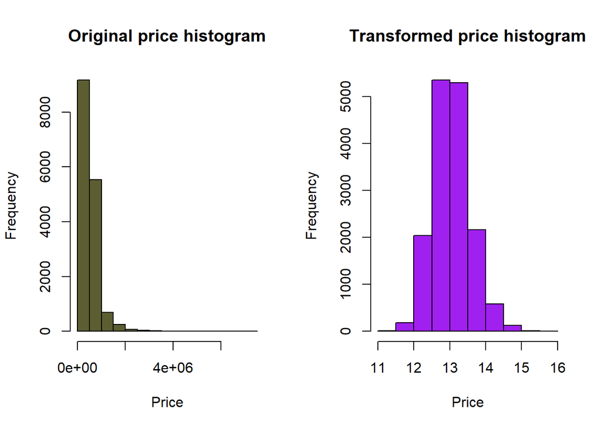

```r
par(mfrow = c(1, 2))
hist(data$price, main = "Original price histogram", xlab = "Price", col ="#5C5E32")
data4$price <- log(data4$price)
hist(data4$price, main = "Transformed price histogram", xlab = "Price", col = "purple")
```

Finally, we will generate our model with this new distribution of the price variable, and then we will check the results.

```r
data5 <- data4
model5 <- lm(data5$price~., data = data5)
summary(model5)
```

```
##
## Call:
## lm(formula = data5$price ~ ., data = data5)
##
## Residuals:
##      Min       1Q   Median       3Q      Max
## -1.22646 -0.15451 -0.00237  0.15112  1.16370
##
## Coefficients:
##                  Estimate Std. Error t value Pr(>|t|)
## (Intercept)     1.608e+02  1.037e+01  15.513  < 2e-16 ***
## bedrooms       -1.576e-02  3.278e-03  -4.809 1.53e-06 ***
## bathrooms       5.220e-02  4.913e-03  10.625  < 2e-16 ***
## sqft_living     2.082e-04  1.331e-05  15.640  < 2e-16 ***
## sqft_lot        6.296e-07  1.117e-07   5.638 1.75e-08 ***
## floors          1.055e-02  5.848e-03   1.804 0.071183 .
## waterfront      4.031e-01  2.532e-02  15.921  < 2e-16 ***
## view            6.221e-02  3.064e-03  20.304  < 2e-16 ***
## condition       7.660e-02  3.446e-03  22.226  < 2e-16 ***
## grade           1.588e-01  3.145e-03  50.483  < 2e-16 ***
## sqft_above      2.467e-05  1.545e-05   1.597 0.110318
## yr_built       -2.241e-01  1.044e-02 -21.464  < 2e-16 ***
## yr_renovated    5.305e-03  6.282e-04   8.445  < 2e-16 ***
## renovated      -1.050e+01  1.254e+00  -8.375  < 2e-16 ***
## lat             1.363e+00  1.517e-02  89.890  < 2e-16 ***
## long           -6.383e-02  1.760e-02  -3.627 0.000288 ***
## sqft_living15   2.215e-04  1.605e-05  13.803  < 2e-16 ***
## sqft_lot15     -1.817e-07  1.117e-07  -1.627 0.103780
## sqft_living2   -8.837e-09  2.112e-09  -4.185 2.87e-05 ***
## yr_built2       5.636e-05  2.667e-06  21.131  < 2e-16 ***
## sqft_living152 -2.666e-08  3.195e-09  -8.345  < 2e-16 ***
## sqft_lot2      -2.502e-13  1.089e-13  -2.298 0.021587 *
## sqft_above2    -5.983e-09  2.938e-09  -2.036 0.041756 *
## ---
## Signif. codes:  0 '***' 0.001 '**' 0.01 '*' 0.05 '.' 0.1 ' ' 1
##
## Residual standard error: 0.2474 on 15742 degrees of freedom
## Multiple R-squared:  0.7759, Adjusted R-squared:  0.7756
## F-statistic:  2478 on 22 and 15742 DF,  p-value: < 2.2e-16
```

In the end we have managed to solve the problems regarding the distribution of the residuals, as they are now distributed according to a normal distribution since the median is close to 0, and the 1st and 3rd quartiles are symmetric, in addition, the model has improved its results significantly a percentage of 77.59% of the variation of the dependent variable is collectively explained now by all the independent variables. It seems that the problem lay in the distribution of the values of the price variable.

# **Conclusion**

For our final model we have applied a transformation to the dependent variable in order to obtain a new distribution that is more favourable for our model. Thanks to this transformation we have been able to get our residuals to follow a distribution closer to the normal distribution and we have also improved the results with respect to the R-squared that we had obtained previously. It is also important to mention that the data regarding the square metres in our last model were squared, which, as we have already mentioned, allowed us to improve the model since these variables do not seem to have a linear relationship with respect to price.

As for the three coefficients to be mentioned, firstly, the number of habitable square metres of the house (**sqft_living**), it is quite intuitive to understand that the more habitable metres, the higher the price of the house, and this is confirmed by the coefficient assigned by the model to this variable, we can see this increase reflected in the coefficient, since being $2.082\cdot10^{-4}$ we can be know that if the rest of the variables remained stable, for each unit that the square metres variable increased, the price would increase by $e^{2.082\cdot10^{-4}}$. On the other hand, the other two coefficients that I would like to mention are latitude (**lat**) and longitude (**long**), since on the one hand latitude has a positive coefficient and the other negative, from here we can extract very valuable information since with this what we know is that a house with the same characteristics will be more expensive the more its latitude increases, since with an increase of one unit in the lat, price would increase according to our model by $e^{1.363}$, on the other hand the same house also with the rest of the variables fixed would decrease its price by $e^{6.383\cdot10^{-2}}$ for each unit of longitude that increases, knowing this we can make estimations to find a region that offers better prices for the same type of house.

Finally, as for the recommendations on how to improve the selling price of the house, in addition to those mentioned above which are related to its geographical position, I would also add, taking into account the results obtained by the model, that the price can be increased by the number of flats, which if there is no special interest in this, could save money by simply buying a house with only one flat but the same square metres, and I would also consider reviewing the cost of renovating a house on your own, as perhaps you can save a lot if you buy a house without renovating it.